# Info 371 PS2

Yasmine Hejazi

## Intro

For this assignment, we will be using data from the Progresa program, a government social assistance program in Mexico. This program, as well as the details of its impact, are described in the paper “School subsidies for the poor: evaluating the Mexican Progresa poverty program”, by Paul Shultz.

```r
data <- read.csv("progresa_sample.csv", stringsAsFactors = FALSE)
```

## Part 1 Descriptive Analysis

### 1.1 Summary Statistics

First, lets report summary statistics (mean, standard deviation, and number of missings) for all of the demographic variables in the dataset (i.e., everything except year, folnum, village). Present the actual levels for ‘progressa’ and ‘poor’.

| Variables | Mean | Std.Dev | NAs |
| --- | --- | --- | --- |
| age | 11.3664595 | 3.1677438 | 0 |
| dist_cap | 147.6744521 | 76.0631335 | 0 |
| dist_sec | 2.4189100 | 2.2341088 | 0 |
| fam_n | 7.2157152 | 2.3529005 | 0 |
| grc | 3.9635366 | 2.4990635 | 6549 |
| grc97 | 3.7053722 | 2.5723873 | 0 |
| hohage | 44.4367167 | 11.6203716 | 10 |
| hohedu | 2.7681036 | 2.6561058 | 0 |
| hohsex | 0.9251845 | 0.2630951 | 20 |
| hohwag | 586.9853124 | 788.1336642 | 0 |
| indig | 0.2983236 | 0.4575252 | 300 |
| min_dist | 103.4475202 | 42.0894408 | 0 |
| sc | 0.8198177 | 0.3843420 | 8453 |
| sc97 | 0.8139224 | 0.3891719 | 3872 |
| sex | 0.5122109 | 0.4998541 | 24 |
| welfare_index | 690.3465635 | 139.4911300 | 210 |

Here we see a table that summarizes the demographic variables in the dataset. `progressa` is a variable with values *basal* which means the student received the “treatment” or program, and *0* which means they did not. `poor` has the values *pobre* which means the student was defined as poor, and *no pobre* which means they were not poor.

### 1.2 Differences at Baseline?

Now let’s investigate the differences in baseline. Are the baseline (1997) demographic characteristics for the poor different in treatment and control villages?

Let’s use a t-Test to determine whether there is a statistically significant difference in the average values of each of the variables in the dataset. We will focus only on the data from 1997 for poor. I will justify removing NAs from the analysis with the fact that a key variable interest that is used to measure enrollment rate, *sc*, has 8453 NA values. Removing those NAs and their corresponding grc NAs will allow us to measure the data that is most relevant to us.

| Variable name | Average value (treatment villages) | Average value (controlled villages) | Difference (Treat - Control) | p_value |
| --- | --- | --- | --- | --- |
| age | 10.7438251 | 10.7855857 | -0.0417607 | 2.474077e-01 |
| dist_cap | 151.8014724 | 154.4920946 | -2.6906222 | 4.361914e-03 |
| dist_sec | 2.3996478 | 2.4006867 | -0.0010389 | 9.680703e-01 |
| fam_n | 7.2810320 | 7.3029394 | -0.0219074 | 4.260542e-01 |
| grc | 3.7092139 | 3.7336533 | -0.0244394 | 3.955066e-01 |
| grc97 | 3.7092139 | 3.7336533 | -0.0244394 | 3.955066e-01 |
| hohage | 43.6312339 | 44.2707173 | -0.6394833 | 2.387419e-06 |
| hohedu | 2.7267292 | 2.6609821 | 0.0657472 | 2.495527e-02 |
| hohsex | 0.9255860 | 0.9233868 | 0.0021993 | 4.795421e-01 |
| hohwag | 550.2070857 | 580.6944519 | -30.4873662 | 2.851315e-04 |
| indig | 0.3167445 | 0.3253064 | -0.0085619 | 1.190039e-01 |
| min_dist | 107.3952314 | 103.0983475 | 4.2968839 | 6.942943e-18 |
| sc | 0.8226965 | 0.8150656 | 0.0076310 | 9.246651e-02 |
| sc97 | 0.8226965 | 0.8150656 | 0.0076310 | 9.246651e-02 |
| sex | 0.5202685 | 0.5065558 | 0.0137127 | 1.959334e-02 |
| welfare_index | 656.8104758 | 661.5935131 | -4.7830373 | 4.048112e-04 |

### 1.3 Interpretation

1. Are there statistically significant differences between treatment and control villages as baseline?
2. Why does it matter if there are differences at baseline?
3. What does this imply about how to measure the impact of the treatment?

We see statistically significant differences between treatment and control villages as baseline where the p-value is < 0.05. We see this happening in *dist_cap*, *hohage*, *hohedu*, *hohwag*, *min_dist*, *sex*, and *welfare_index*. We should see if there are differences at baseline because it wouldn’t be good if there was a big difference - this would mean that the randomly selected people who receive treatment didn’t turn out so “random” where there are already differences showing, introducing bias, and we would therefore need to account or adjust for this. Measuring the impact of the treatment is difficult because the two groups won’t be exactly the same - we will need to figure out how to account for these differences.

### 1.4 Graphical exploration, part 1

For each level of household head education let’s compute the average enrollment rate in 1997 and create a scatterplot that shows this relationship. We can observe that as Head of Household Education increases, average enrollment also increases, with an outlier where Head of Household Education = 20. Perhaps they are too good for school :^)

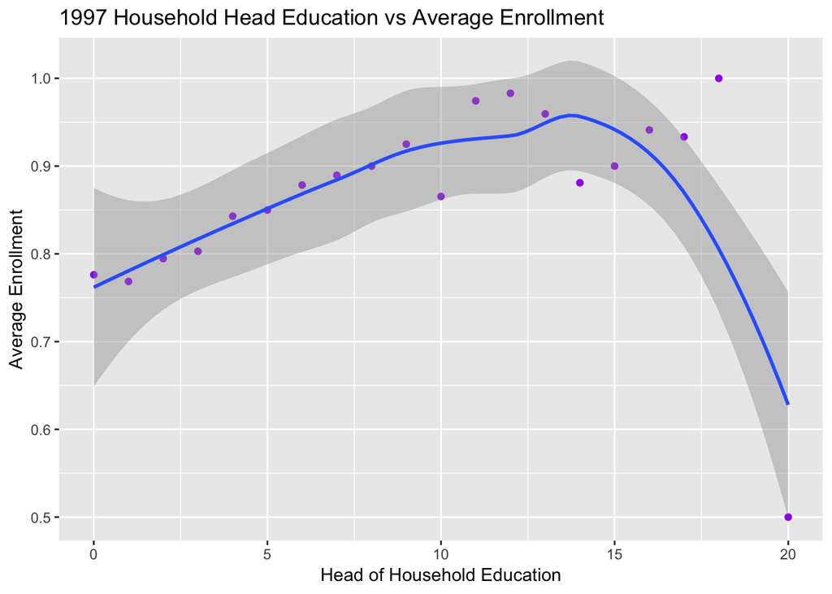

### 1.5 Graphical exploration, part 2

Create a histogram of village enrollment rates **among poor households in treated villages**, before and after treatment. Specifically, for each village, calculate the average rate of enrollment of poor households in treated villages in 1997, then compute the average rate of enrollment of poor households in treated villages in 1998. Create two separate histograms showing the distribution of these average enrollments rates, one histogram for 1997 and one histogram for 1998. On each histogram, draw a vertical line that intersects the x-axis at the average value (across all households). Does there appear to be a difference? Is this difference statistically significant?

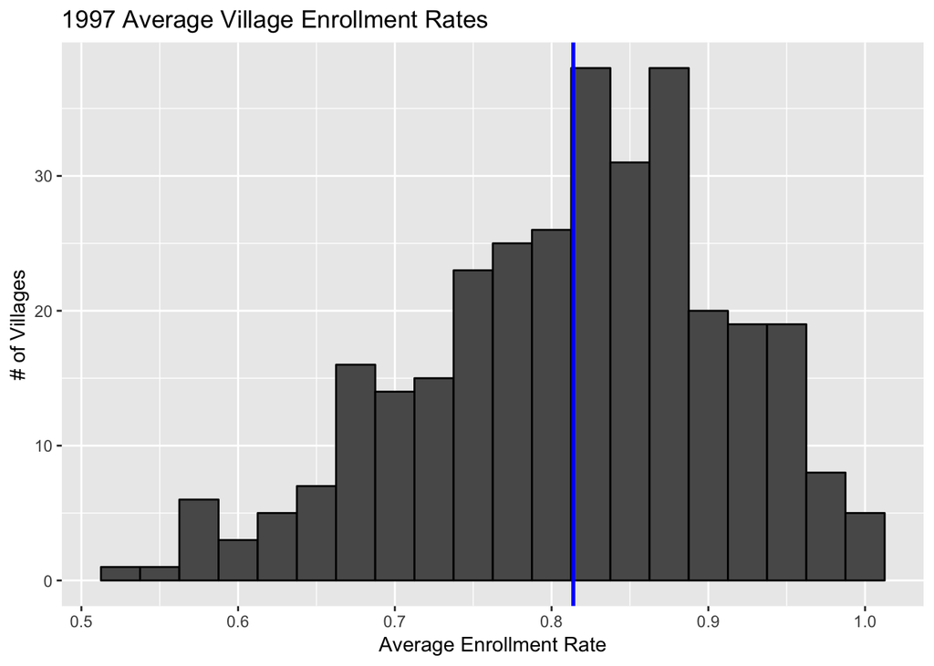

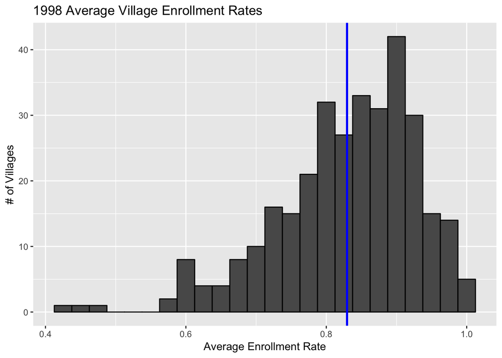

Let’s perform a t test to see if the difference is statistically significant.

```
##
##  Welch Two Sample t-test
##
## data:  data1997_treated$mean and data1998_treated$mean
## t = -2.0157, df = 637.02, p-value = 0.04425
## alternative hypothesis: true difference in means is not equal to 0
## 95 percent confidence interval:
##  -0.0309885069 -0.0004050795
## sample estimates:
## mean of x mean of y
## 0.8138394 0.8295362
```

The average enrollment rate increases over time. We see this in a difference of mean from **0.8138** in 1997 to **0.8295** in 1998. A left-skew is shown in both histograms; the second histogram becomes more left-skewed, showing that enrollment rate increased in the year. We can conclude that the program is significant in average enrollment rate because we have a **p-value of 0.0442493**, which is less than 0.05.

## Part 2: Measuring Impact

### 2.1 Cross-Sectional Estimator: T-test

Begin by estimating the impact of Progresa using “simple differences.” Restricting yourself to data from 1998 (after treatment), calculate the average enrollment rate among poor households in the Treatment villages and the average enrollment rate among poor households in the control villages. Use a t-test to determine if this difference is statistically significant. What do you conclude?

```
##
##  Welch Two Sample t-test
##
## data:  treated$sc and untreated$sc
## t = 7.9247, df = 19374, p-value = 2.409e-15
## alternative hypothesis: true difference in means is not equal to 0
## 95 percent confidence interval:
##  0.02885251 0.04781536
## sample estimates:
## mean of x mean of y
## 0.8492570 0.8109231
```

We again see an increase in average enrollment rate in treated villages from untreated villages by **0.0383339** in 1998. We can conclude that the program is significant in average enrollment rate because we have a **p-value of 2.409211110^{-15}**, which is less than 0.05.

### 2.2 Cross-Sectional Estimator: Regression

Estimate the effects of Progresa on enrollment using a regression model, by regressing the 1998 enrollment rates of the poor on treatment assignment. Do not include any additional control variables.

Discuss the following:

1. Based on this model, how much did Progresa increase the likelihood of a child enrolling?
2. How does your regression estimate compare to your t-test estimate from part 2.1?
3. Based on this regression model, can we reject the null hypothesis that the treatment effects are zero?
4. What is the counterfactual assumption underlying this regression?

Note: I recommend to use statsmodels.formula.api as this allows to use convenient R-style formulas and provedes nice summaries of the results.

```
##
## Call:
## lm(formula = sc ~ progresa, data = data1998)
##
## Residuals:
##     Min      1Q  Median      3Q     Max
## -0.8465  0.1535  0.1535  0.1924  0.1924
##
## Coefficients:
##               Estimate Std. Error t value Pr(>|t|)
## (Intercept)   0.807637   0.003660 220.676   <2e-16 ***
## progresabasal 0.038842   0.004647   8.359   <2e-16 ***
## ---
## Signif. codes:  0 '***' 0.001 '**' 0.01 '*' 0.05 '.' 0.1 ' ' 1
##
## Residual standard error: 0.3736 on 27448 degrees of freedom
##   (5246 observations deleted due to missingness)
## Multiple R-squared:  0.002539,   Adjusted R-squared:  0.002503
## F-statistic: 69.87 on 1 and 27448 DF,  p-value: < 2.2e-16
```

### 2.3 Multiple Regression

Re-run the above regression estimated but this time include a set of relevant control variables. Include, for instance, age, distance to a secondary school, gender, education of household head, welfare index, indigenous, etc.

1. How do the controls affect the point estimate of treatment effect?
2. How do the controls affect the standard error on the treatment effect?
3. How do you interpret the differences (or similarities) between your estimates of 2.2 and 2.3?

```
##
## Call:
## lm(formula = sc ~ progresa + age + dist_sec + sex + hohedu +
##     welfare_index + indig + hohwag, data = data1998)
##
## Residuals:
##      Min       1Q   Median       3Q      Max
## -1.17780 -0.10000  0.05982  0.22265  0.65942
##
## Coefficients:
##                 Estimate Std. Error t value Pr(>|t|)
## (Intercept)    1.503e+00  1.433e-02 104.854  < 2e-16 ***
## progresabasal  3.516e-02  4.003e-03   8.783  < 2e-16 ***
## age           -6.551e-02  6.888e-04 -95.101  < 2e-16 ***
## dist_sec      -1.173e-02  8.780e-04 -13.361  < 2e-16 ***
## sex            3.096e-02  3.882e-03   7.976 1.57e-15 ***
## hohedu         8.576e-03  7.872e-04  10.895  < 2e-16 ***
## welfare_index  3.241e-05  1.724e-05   1.880   0.0602 .
## indig          4.670e-02  4.173e-03  11.192  < 2e-16 ***
## hohwag        -9.294e-07  2.803e-06  -0.332   0.7402
## ---
## Signif. codes:  0 '***' 0.001 '**' 0.01 '*' 0.05 '.' 0.1 ' ' 1
##
## Residual standard error: 0.3203 on 27258 degrees of freedom
##   (5429 observations deleted due to missingness)
## Multiple R-squared:  0.2671, Adjusted R-squared:  0.2669
## F-statistic:  1242 on 8 and 27258 DF,  p-value: < 2.2e-16
```

### 2.4 Difference-in-Difference, version 1 (tabular)

Thus far, we have computed the effects of Progresa by estimating the difference in 1998 enrollment rates across villages. An alternative approach would be to compute the treatment effect using a difference-in-differences framework.

Begin by estimating the average treatment effects of the program for poor households using data from 1997 and 1998. Specifically, calculate:

1. the difference (between 1997 and 1998) in enrollment rates among poor households in treated villages
2. the difference (between 1997 and 1998) in enrollment rates among poor households in control villages.
3. The difference between these two differences is your estimate. (i.e. Difference-in-Differences estimate = [Y_T(98) - Y_C(98)] - [Y_T(97) - Y_C(97)])

The difference (between 1997 and 1998) in enrollment rates among poor households in treated villages: **0.0266**

The difference (between 1997 and 1998) in enrollment rates among poor households in control villages: **-0.0041**

The difference between these two differences is your estimate: **0.030703**

Our simple differences value was **0.0383339**, which is a little more than our current estimate. The counterfactual assumption underlying this estimate is that there wouldn’t be a difference between treatment and controlled average enrollment rates for 1997 and 1998 if the progresa treatment existed.

### 2.5 Difference-in-Difference, version 2 (regression)

Now use a regression specification to estimate the average treatment effects of the program in a difference-in-differences framework. Include at least 5 control variables.

1. What is your estimate of the impact of Progresa? Be very specific in interpreting your coefficients and standard errors, and make sure to specify exactly what units you are measuring and estimating.
2. How do these estimates of the treatment effect compare to the estimates based on the simple difference?
3. How do these estimates compare to the difference-in-difference estimates from 2.4 above? What accounts for these differences?
4. What is the counterfactual assumption underlying this regression?

```
##
## Call:
## lm(formula = sc ~ (progresa * poor) + age + dist_sec + sex +
##     hohedu + welfare_index + indig + hohwag, data = data_both_years)
##
## Residuals:
##      Min       1Q   Median       3Q      Max
## -1.20575 -0.11530  0.06229  0.23346  0.65962
##
## Coefficients:
##                           Estimate Std. Error  t value Pr(>|t|)
## (Intercept)              1.478e+00  1.207e-02  122.444  < 2e-16 ***
## progresabasal            2.717e-02  6.600e-03    4.117 3.84e-05 ***
## poorpobre               -1.666e-03  6.101e-03   -0.273 0.784846
## age                     -6.503e-02  4.274e-04 -152.152  < 2e-16 ***
## dist_sec                -1.099e-02  6.035e-04  -18.207  < 2e-16 ***
## sex                      3.304e-02  2.522e-03   13.097  < 2e-16 ***
## hohedu                   7.930e-03  4.910e-04   16.151  < 2e-16 ***
## welfare_index            4.122e-05  1.108e-05    3.720 0.000199 ***
## indig                    5.091e-02  2.821e-03   18.049  < 2e-16 ***
## hohwag                  -4.183e-07  1.627e-06   -0.257 0.797154
## progresabasal:poorpobre -8.445e-03  7.178e-03   -1.177 0.239393
## ---
## Signif. codes:  0 '***' 0.001 '**' 0.01 '*' 0.05 '.' 0.1 ' ' 1
##
## Residual standard error: 0.3265 on 67111 degrees of freedom
## Multiple R-squared:  0.2742, Adjusted R-squared:  0.2741
## F-statistic:  2535 on 10 and 67111 DF,  p-value: < 2.2e-16
```

Progresa has an increase (coeff) of **0.02717** to average enrollment rate. The t-value of progresa is **4.117** and shows that the variable is very significant in our regression. Our standard error for progressa is **0.0066**. This may suggest that because the standard error is higher than our previous models, the other models may show more accuracy. Looking at the interaction variable, the estimate is a negative value. We see that the using the control variables that we used, there was very minimal difference in the enrollment rate because of the treatment.

### 2.6 Summary

Based on all the analysis you have undertaken to date, do you believe that Progresa had a causal impact on the enrollment rates of poor households in Mexico? Explain by referring to the methods and results above.